# Le castor, ingénieur des écosystèmes – Effets sur la qualité de l’eau et les écosystèmes d’eau douce

## Le castor, ingénieur des écosystèmes–Effets sur la qualité de l’eau et les écosystèmes d’eau douce

Colloque 2026 : Eau propre

Dr. Leonardo Capitani  
Senior Scientist, Département d’écologie aquatique, Eawag

[figure not shown]

leomarameo7.github.io

23 octobre 2026

## Diapositives et liens

[figure not shown]

[figure not shown]

**Scanner pour télécharger**

[figure not shown]

## Remerciements

[figure not shown]

… et bien d’autres chercheuses, chercheurs et parties prenantes !

## Message principal de cet exposé

Le castor crée localement des zones humides résilientes au climat

Photos et effets : Fairfax & Westbrook (2024), Fig. 2 ; texte recomposé

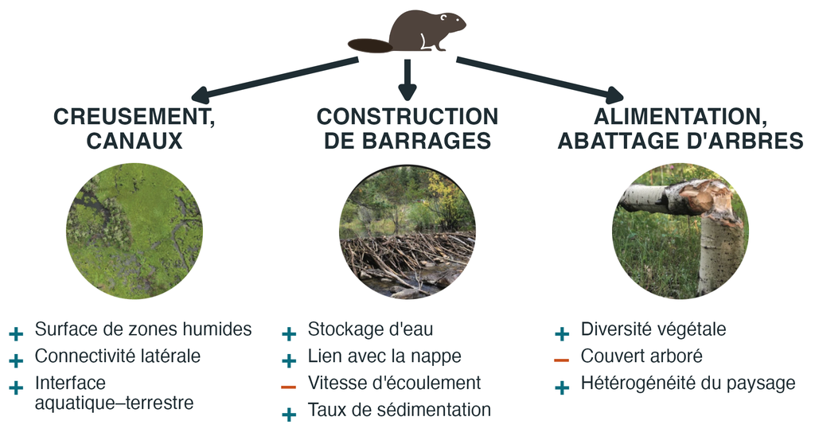

## Plan de la présentation

1. **Qualité de l’eau :** carbone et nutriments
2. **Biodiversité :** habitats et espèces
3. **Résilience :** crues et sécheresses
4. **Gestion :** vivre avec les castors

Synthèse internationale + cas suisses

## Cycle de vie et régime alimentaire du castor

Reproduction lente : peu de jeunes, longue vie familiale

Castor d’Eurasie ; Tab. 1.1 et chapitres 5, 6 et 10 dans Rosell & Campbell-Palmer (2022) ; photo : Kjell-Erik Moseid, Fig. 5.12

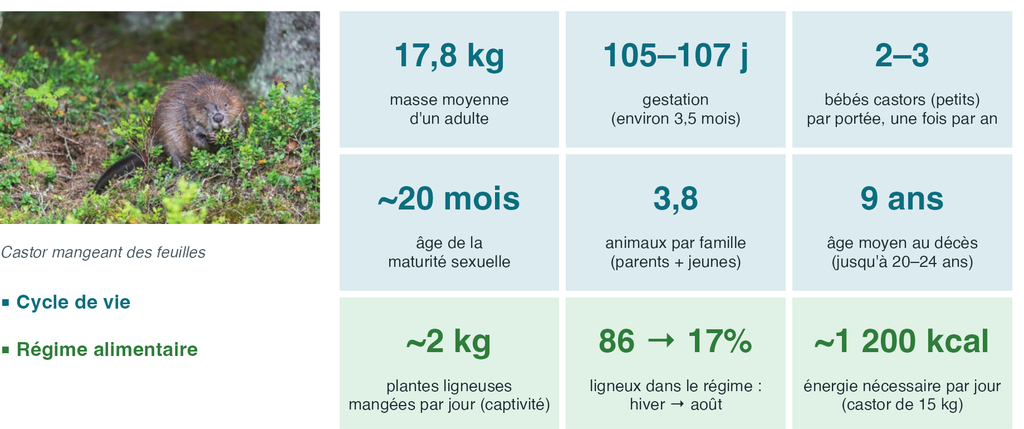

## Les castors reviennent partout en Europe

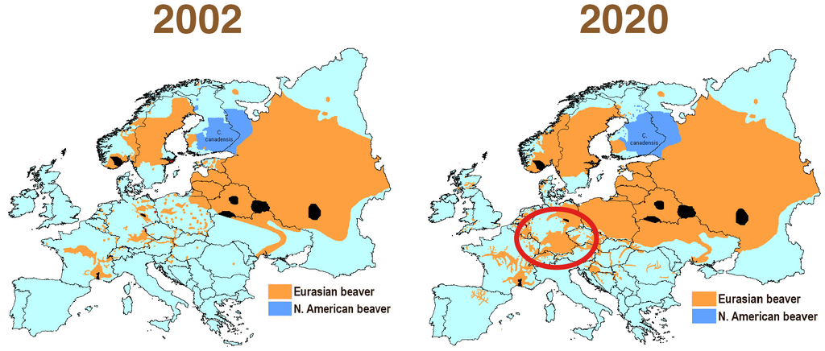

Suisse, 2022 :  
4 900 castors

Les castors recolonisent l’Europe

Sources : [Halley et al. 2020, Mammal Review 51, 1–24](https://doi.org/10.1111/mam.12216) (cartes) ; [Angst et al. 2023, Biberbestandeserhebung 2022, info fauna](https://www.infofauna.ch/de/aktuell/2023-07-06_biber-bestandeserhebung-2022#gsc.tab=0) (Suisse)

## Combien de castors ?

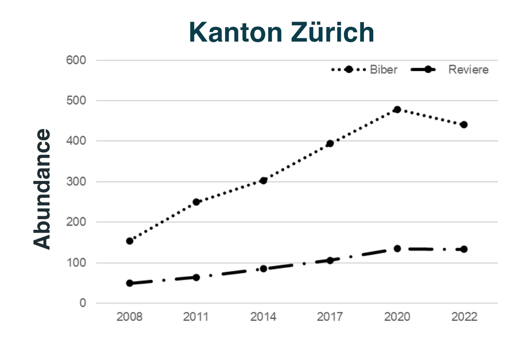

Données : [Nationale Biberfachstelle / info fauna 2023](https://www.infofauna.ch)

La reprise se stabilise

## Vivre avec les castors : le coût des dégâts

Les indemnisations ont augmenté sur 30 ans (1988–2021)

Source : [Angst et al. 2023, Biberbestandeserhebung 2022, info fauna](https://www.infofauna.ch/de/aktuell/2023-07-06_biber-bestandeserhebung-2022#gsc.tab=0), Fig. 37 ; dégâts aux cultures et aux forêts, 1988–2021

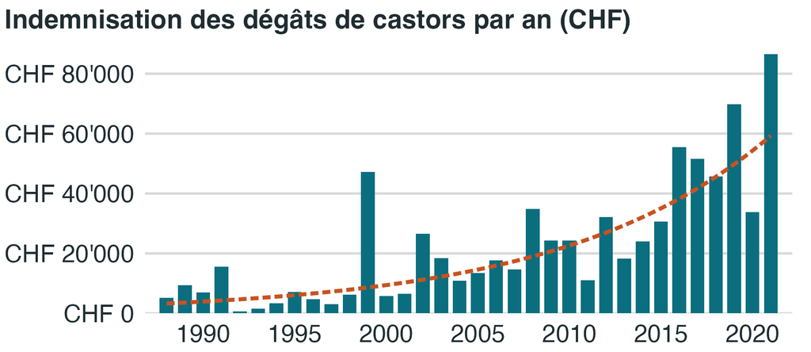

## Impacts hydrologiques

Les castors réduisent la connectivité longitudinale et augmentent la connectivité latérale

Modifié d’après Brazier *et al.* (2021), Fig. 2 : étapes a, c, e, f

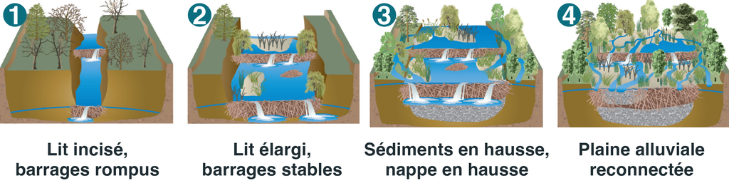

## Qualité de l’eau · Pourquoi le cycle des nutriments ?

Nutriments et matière organique font vivre les écosystèmes

Modifié d’après Jansen *et al.* (2021), Fig. 5 : cercles rouges et cours d’eau ajoutés

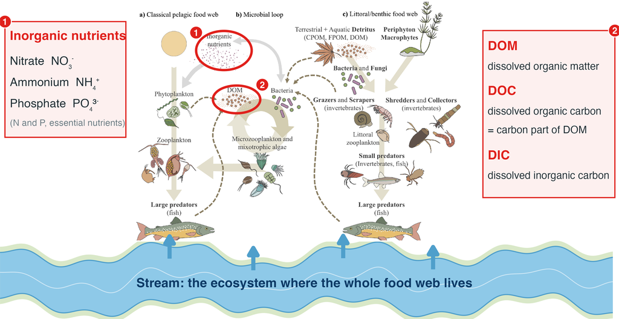

## Qualité de l’eau · Synthèse internationale : C et nutriments

Bilans de carbone et de nutriments : pas de direction unique

Modifié d’après [Larsen et al. 2021, Earth-Science Reviews 218, 103623](https://doi.org/10.1016/j.earscirev.2021.103623), Fig. 15 : modèle conceptuel ; flèches et nombres (études avec ce sens de variation sur toutes les études) issus de leur synthèse de la littérature, Fig. 16 : 37 études sur la qualité de l’eau, surtout en Amérique du Nord, 1982–2021

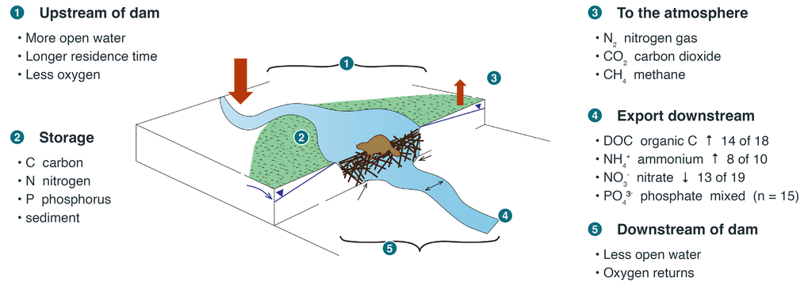

## Qualité de l’eau : le cas suisse

Les étangs de castors sont des points de contrôle locaux du COD

Capitani et al., en prép., Fig. 4

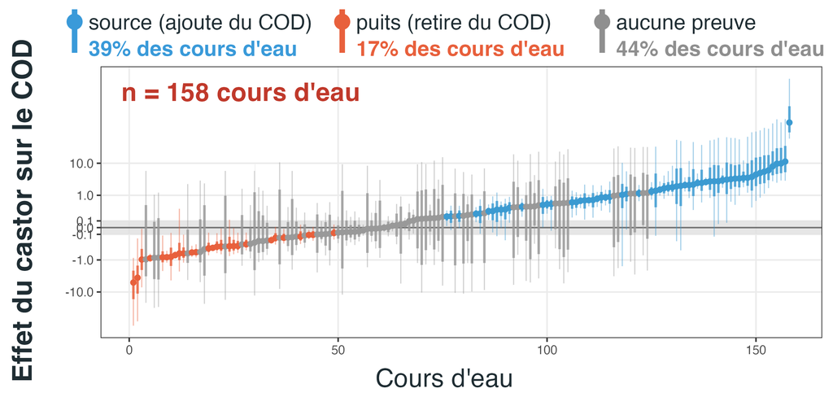

## Qualité de l’eau · facteurs de l’influence du castor

Les castors ralentissent l’eau ; algues et plantes ajoutent du COD

Capitani et al., en prép., Fig. 3

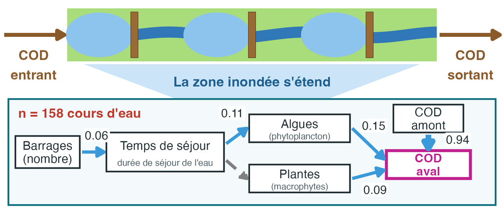

## Biodiversité : le cas suisse

Les castors influencent la biodiversité des cours d’eau

Source : [Moser et al. 2026, Journal of Applied Ecology](https://doi.org/10.1111/1365-2664.70439)

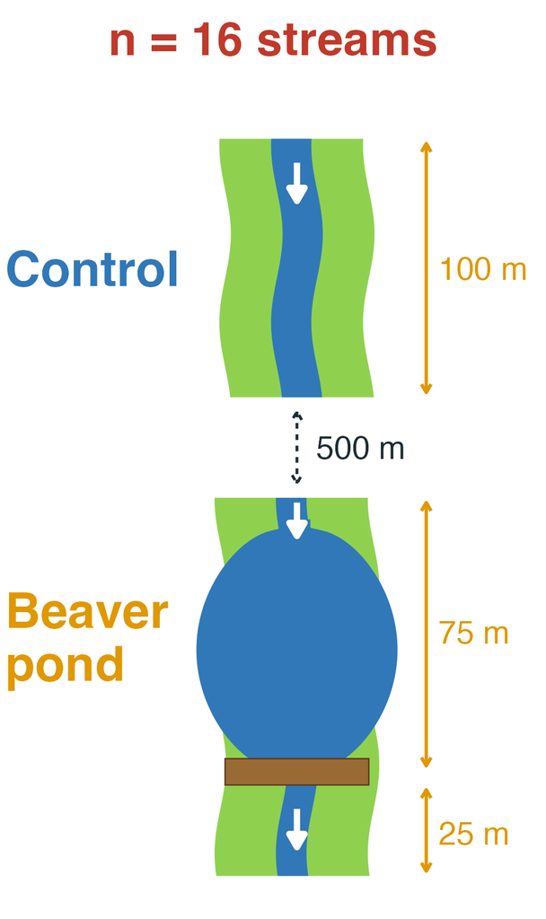

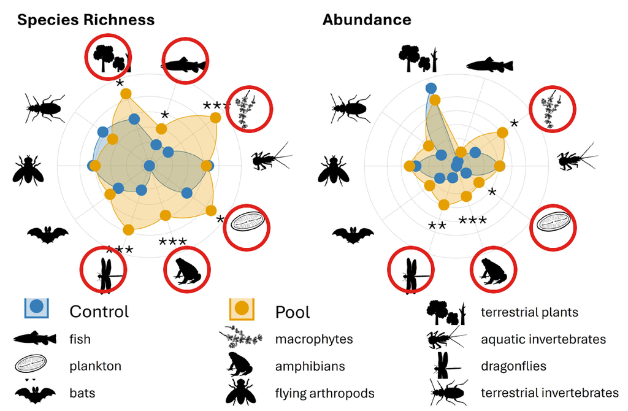

## Biodiversité · Chauves-souris près des étangs de castors

Apport du castor : habitats plus complexes et plus de nourriture

Figure : [Browning 2025](https://doi.org/10.1111/1365-2656.70144) ; données : [Moser, Capitani et al. 2025](https://doi.org/10.1111/1365-2656.70136) ; photos : [JeanRoulin](https://commons.wikimedia.org/wiki/File:Barbastella_barbastellus.jpg) CC BY-SA, [R. Bigonneau](https://commons.wikimedia.org/wiki/File:Myotis_emarginatus.jpg) CC BY (Wikimedia)

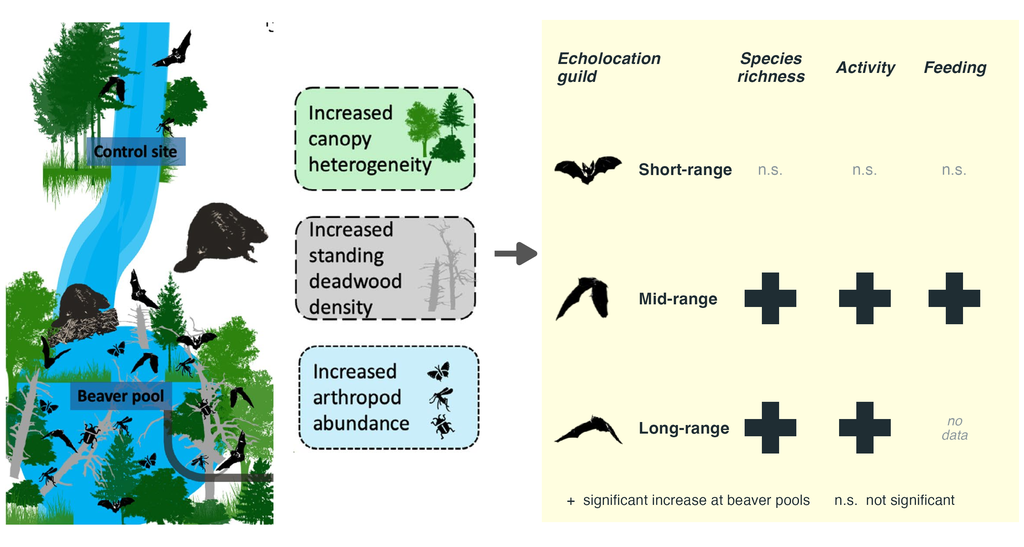

- Portée moyenne : gain max.
- Facteur : bois mort
- Espèces menacées :

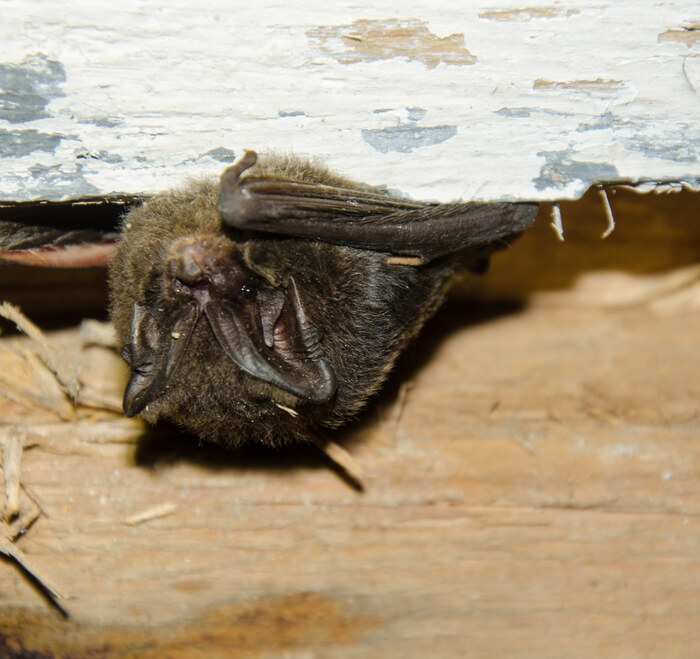

Barbastelle d’Europe

*Barbastella barbastellus*

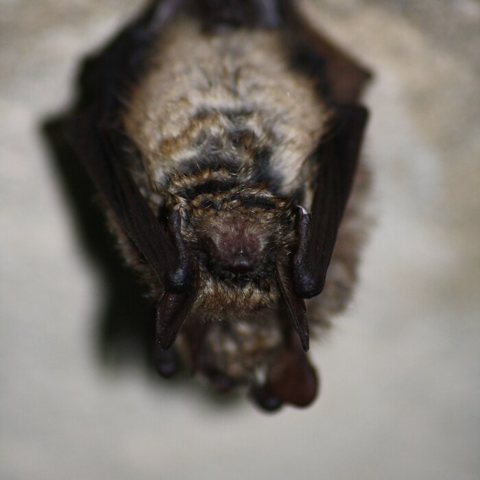

Murin à oreilles échancrées

*Myotis emarginatus*

## Résilience : le cas belge

[figure not shown]

Site d’étude : Chevral, Ardennes, Belgique

Pointes de crue aplanies, étiages plus élevés

Redessiné d’après [Nyssen et al. 2011, Journal of Hydrology 402, 92–102](https://doi.org/10.1016/j.jhydrol.2011.03.001), Fig. 12 (aussi Fig. 8 dans Larsen et al. 2021)

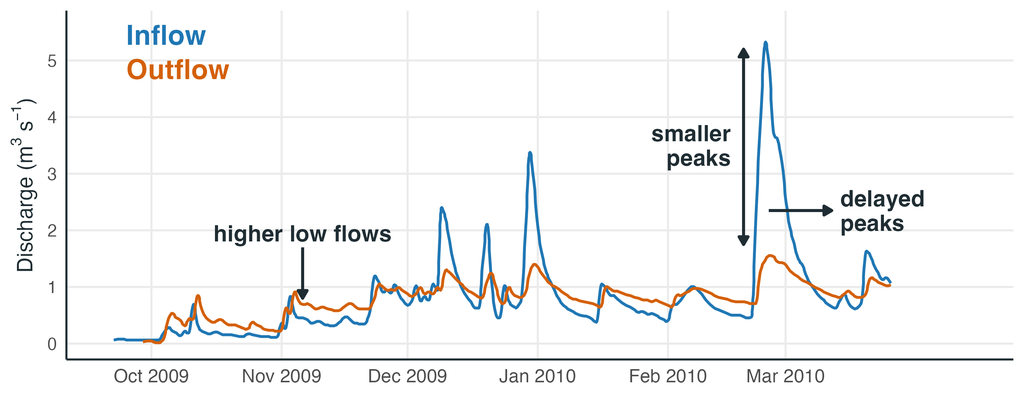

## Résilience · Stocker l’eau, amortir les débits

Les barrages amortissent sécheresses et crues

Sources : [Dittbrenner et al. 2022, Ecosphere 13, e4168](https://doi.org/10.1002/ecs2.4168) ; Puttock *et al.* (2017) ; Hood 2012 dans Rosell & Campbell-Palmer (2022)

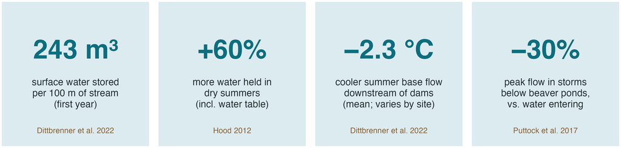

## Gestion du castor : conflits et solutions

Chaque conflit a une solution pratique

Tab. 11.1 dans Rosell & Campbell-Palmer (2022)

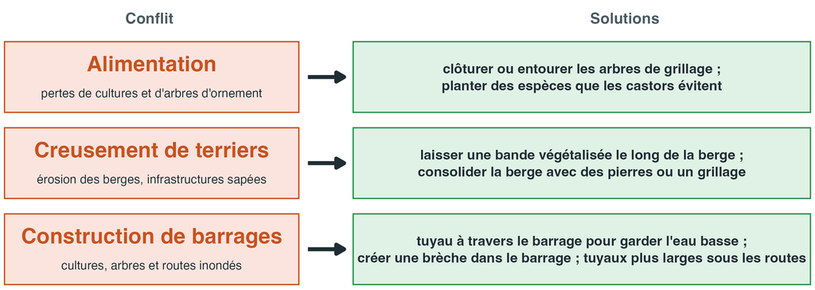

## Gestion du castor : zonage en République tchèque

[figure not shown]

Le zonage sépare zones protégées et zones de conflit

Vorel et al. 2016, décrit dans Rosell & Campbell-Palmer (2022), p. 422–423

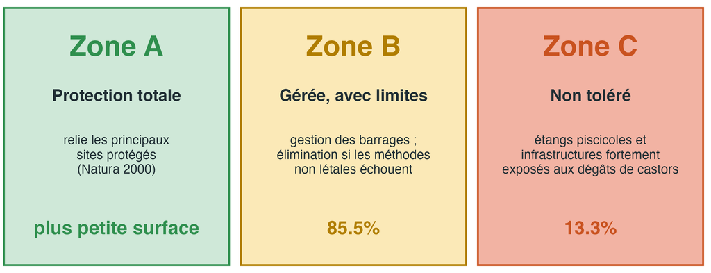

## Gestion du castor : le cas suisse

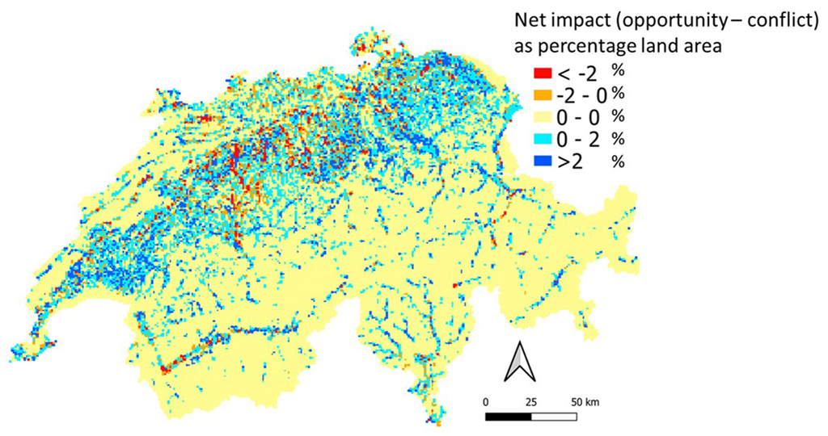

Fig. 6 et tab. 4 dans [Dennis et al. 2024, Global Ecology and Conservation 56, e03304](https://doi.org/10.1016/j.gecco.2024.e03304)

[Biber-Auenmodell](https://www.infofauna.ch/de/artenfoerderung/2024_modellierung-von-biber-auengebieten-der-schweiz#gsc.tab=0)

[figure not shown]

Plaine alluviale : 450 km²

- Facteur : pente du lit

[figure not shown]

- 298 km² (66 %) opportunité
- 132 km² (29 %) conflit

Maximiser la revitalisation, minimiser les conflits

## Gestion du castor : comment procéder ?

La gestion du castor doit tenir compte du contexte social

Redessiné d’après [Dennis et al. 2024, Global Ecology and Conservation 56, e03304](https://doi.org/10.1016/j.gecco.2024.e03304)

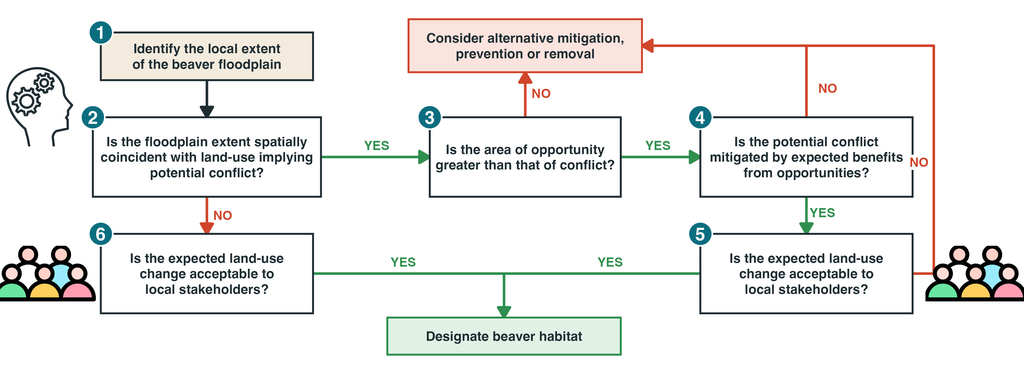